# Week 2, Meeting 2

# Finish Lecture 3

## Separation of Concerns

Structuring our solution by organizing it well. Let’s think about a data science workflow:

- Data Acquisition - Keep data acquisition code separate from analysis and modeling code. Write the code to obtain the data and save the code and data for further use.
- Data Cleaning and Preprocessing - In a different script or notebook, address missing values, encoding categorical variables, normalize numeric variables.
- Exploratory Data Analysis (EDA) - in a yet another notebook or script, explore the data and keep this separated from the data acquisition, cleaning, preprocessing etc.
- Feature Engineering - We might write functions in yet another script to create new features and keep them separate from data acquisition, cleaning, preprocessing, EDA, modeling.
- Model Training & Testing - yet another script or notebook where the actual modeling occurs.

## How Separation of Concerns can help

- Improves reproducibility (given the clarity of the solution).
- Helps collaboration because team members can work on the parts independently.
- Problems or improvements in one part should not affect the other parts
- Scales up well because it will be easier to extend models, preprocessors, etc.

# Writing Functions

## Functions

- Writing functions helps you with:
- 1
- 2
- 3
- 4
- 5
- 6
- Reusing code and its logic without copying and pasting
  - Without functions or scripts you might be copying and pasting a lot.
  - Writing functions allows you to encapsulate your logic, making your programming reusable and easier to maintain.
  - Define your logic once and call on it many times
- Efficiency and Automation
  - Python is excellent for automating repetitive tasks.
  - If you plan to work with data in the future or generate reports, presentations, etc. scripts can save time.
  - Example: Use Python to automate downloading data, cleaning the data, and then saving a formatted data analysis report.
- Debugging and Error Handling
  - Using functions makes identifying errors easier because typically a function should only do one task well (separation of concern?) - this helps us isolate issues/problems.
  - Programming our own functions and writing scripts lets us log errors and identify errors – helps us to track down errors in our code
- Scalability and Collaboration
  - Scripts and modularized code scale better for larger projects.
  - When working in a team, properly structured Python code is far easier to share and easier for others to understand.
- Gaining access to advanced features of Python
  - Many Python libraries (e.g., pandas, NumPy) assume you are able to define functions, use classes, and write scripts.
  - Some machine learning models often require defining custom data transformations via object-oriented programming
- Employability
  - Given the team-based work environment, many employers expect Python programmers to write structured, modular code
  - This means knowing how to write functions, using scripts, and implementing object-oriented programming (next week)
  - Programming languages come and go, but developing the underlying creative skills will serve you well.

## def

**This is the keyword for defining functions in Python**

- It must be followed by the function name and then a parenthesized list of formal parameters and a colon.
- The statements that form the body of the function start at the next line, and must be indented.

## Function examples

- 1
- 2
- 3
- 4
- Simplest function ever
- It’s a little silly but it has everything a function requires.

```python
def greet():
    return "Hello, World!"

print(greet())
```

```
Hello, World!
```

- Customizing the simplest function ever by adding the parameter “name” to the function.
- Parameters appear in the function definition

```python
def greet(name):
    return f"Hello, {name}"

her_name = "Jisoo" # the variable her_name, value "Jisoo"

print(greet(her_name))
```

```
Hello, Jisoo
```

A little more complicated, there are two for loops here can you figure out what they do? (hint: identify the sequences first)

```python
def greet(names):
    output = [] # an empty list
    for name in names:
        #output.append(name) # this will work but the following is nicer
        output.append(f"Hello, {name}!")  # Adds "Hello"
    return output

bp= ["Jisoo", "Jennie", "Rosé", "Lisa"]

print(greet(bp))

for whatever in greet(bp):
    print(whatever)

#for _ in greet(bp): # _ is a wild card
    #print(_)
```

```
['Hello, Jisoo!', 'Hello, Jennie!', 'Hello, Rosé!', 'Hello, Lisa!']
Hello, Jisoo!
Hello, Jennie!
Hello, Rosé!
Hello, Lisa!
```

We are working with lists here, so a list comprehension makes sense followed by the join method for strings:

```python
def greet(names):
      return [f"Hello, {name}!" for name in names]

bp= ["Jisoo", "Jennie", "Rosé", "Lisa"]

print('\n'.join(greet(bp)))
```

```
Hello, Jisoo!
Hello, Jennie!
Hello, Rosé!
Hello, Lisa!
```

## Basic Function definition

- A basic function takes input and returns output.
- Most of our functions in Stats 21 will be basic

```python
nj = ['Hanni', 'Hyein', 'Haerin', 'Danielle', 'Minji']
# new input

print('\n'.join(greet(nj)))
```

```
Hello, Hanni!
Hello, Hyein!
Hello, Haerin!
Hello, Danielle!
Hello, Minji!
```

## And still more practice with def

- while
- sorted
- sorted() 1
- sorted() 2
- From the Python documentation, example using while

```python
def fib(n):    # write Fibonacci series less than n
    """Print a Fibonacci series less than n."""
    a, b = 0, 1 # unpacking a tuple
    while a < n:
        print(a, end=' ')
        a, b = b, a+b
    print()

# Now call the function we just defined:
fib(2000)
```

[output not shown]

- sorted() is a built-in function, at its simplest it just takes an iterable and does what you think it should do:

```python
spells = ["Expelliarmus", "Colloshoo", "Legilimens","Impedimenta", "Confundo", "Finite Incantatem","Incarcerous"]
nums = (8, 6, 7, 5, 3, 0, -9)

print(sorted(spells))
print(sorted(nums))
```

```
['Colloshoo', 'Confundo', 'Expelliarmus', 'Finite Incantatem', 'Impedimenta', 'Incarcerous', 'Legilimens']
[-9, 0, 3, 5, 6, 7, 8]
```

- But sorted() can take another function as an argument, this helps us transition into “higher order functions”
- sorted() will use that function to compute a value for each element before comparing them.

```python
spells = ["Expelliarmus", "Colloshoo", "Legilimens","Impedimenta", "Confundo", "Finite Incantatem","Incarcerous"]

sorted_spells = sorted(spells, key=len)
print(sorted_spells)
```

```
['Confundo', 'Colloshoo', 'Legilimens', 'Impedimenta', 'Incarcerous', 'Expelliarmus', 'Finite Incantatem']
```

- lambdas are anonymous functions (key= takes a function) they are small and inline
- syntax lambda argument(s): expression

```python
spells = ["Expelliarmus", "Colloshoo", "Legilimens","Impedimenta", "Confundo", "Finite Incantatem","Incarcerous"]

sorted_spells2 = sorted(spells, key=lambda spells: spells[::-1]) # what does[::-1] do?
print(sorted_spells2)
```

```
['Impedimenta', 'Finite Incantatem', 'Confundo', 'Colloshoo', 'Legilimens', 'Expelliarmus', 'Incarcerous']
```

## Takeaways from Lecture 3

- Proposing a structure for getting started with writing functions in Python
- Know about the fundamental parts of a Python script
- Try a list comprehension
- Consider the basic function’s simple structure: “Input - Process - Output” and what needs to happen or what can happen at each step.
- Introduced the idea of using information from additional functions (e.g. lambda) which will bridge the gap from simple to complex.

# Activity

- Please gather together in small groups, please make sure at least one member has a laptop
- for credit: minimum group size 3, optimal maximum group size 6 but larger is OK
- please introduce yourselves and always try to learn a new name or invite someone in who doesn’t have a group
- please take a group photo, annotate with with names or add names as a comment during upload
- upload a photo individually for attendance credit

## Task Analysis on a Pet Age Calculator

- Suppose a pet retailer has asked your team to program a Pet Age Calculator. They want a Python script that allows a user to input a pet’s age in years after selecting pet type (dog, cat, hamster, bird), and then converts the pet’s age to an estimated human equivalent. They have supplied the formulas:
  - 15 human years equals the first year of a medium-sized dog’s life. Year two for a dog equals about nine years for a human. And after that, each human year would be approximately five years for a dog
  - A cat’s first year is 15 human years, the second year adds 9 more, and each year after that is roughly equivalent to 4 human years
  - For a hamster, every 14 days of life is equivalent to a human year
  - Multiply bird age by 5 to estimate the human equivalent.
- Please suggest ways to break this down into a set of subproblems.
  - How should you structure the calculations? One big function for all four animals or one for each type?
  - Will you need other libraries to calculate age?
  - How should you capture the animal’s type and age? I haven’t taught this to you, but would your team want a GUI for users to input information? (…ask a chatbot?)

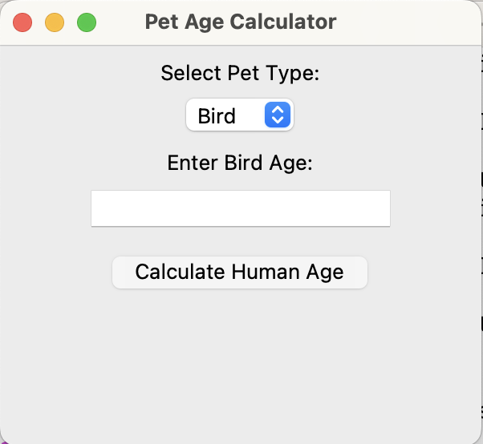

## A little more practice with def

- Dog
- Bird
- Together
- Try that dog age calculation

```python
def dog_to_human_years(dog_age):
    """15 human years equals the first year of a
    medium-sized dog’s life.
    Year two for a dog equals about nine years for a human.
    And after that, each human year would be
    approximately five years for a dog."""
    pass

# try it with different arguments
print(dog_to_human_years(17))
print(dog_to_human_years(-1))
print(dog_to_human_years("Waldo"))
```

- The example from Week 1

```python
def bird_to_human_years(bird_age):
    if bird_age <= 0:
        return "Age must be a positive number."
    return f"Your bird is {bird_age * 5} in human years"

bird_age = float(input("What is the bird's age? "))
print(bird_to_human_years(bird_age))
```

- Let’s put them together in one script, still basic
- But now a function that puts the two smaller ones together

```python
"""
should have a docstring about here
"""

def dog_to_human_years(dog_age):
    """15 human years equals the first year of a
    medium-sized dog’s life.
    Year two for a dog equals about nine years for a human.
    And after that, each human year would be
    approximately five years for a dog."""
    pass

def bird_to_human_years(bird_age):
    if bird_age <= 0:
        return "Age must be a positive number."
    return f"Your bird is {bird_age * 5} in human years"

def pet_age_calculator():
    """Calculates the human age of the pet based on the pet type and ask the user for input"""
    print("Welcome to the Pet Age Calculator!")
    print("Supported pets are: Dog, Bird")

    pet_type = input("What type of pet do you have? ").strip().lower()

    if pet_type in ["dog", "bird"]:
            pet_age = int(input(f"Enter your {pet_type}'s age in years: "))

            if pet_type == "dog":
                human_age = dog_to_human_years(pet_age)
            elif pet_type == "bird":
                human_age = bird_to_human_years(pet_age)

            print(f"Your {pet_type} is approximately {human_age} human years old!")
    else:
        print("Sorry, this calculator only supports dogs and birds.")

# run it
if __name__ == "__main__":
    pet_age_calculator()
```

# More on writing Functions

## Local, Enclosing, & Global Scope

- Before we move to errors, it is useful to discuss **LEGB**
- Stands for **L**ocal, **E**nclosing, **G**lobal and **B**uilt-In
- And refers to the order in which Python resolves variable names.
- Understanding this order will help with the debugging of errors when writing our functions.
- And decrease frustration/build confidence

## A symbol table

The built-in function locals() can reveal the symbol table.

```python
def my_function():
    x = 10
    y = 20
    print(locals())  # Print the local symbol table

my_function()
print(x) # throws a NameError
```

```
{'x': 10, 'y': 20}
```

```
---------------------------------------------------------------------------
NameError                                 Traceback (most recent call last)
Cell In[9], line 7
      4     print(locals())  # Print the local symbol table
      6 my_function()
----> 7 print(x) # throws a NameError

NameError: name 'x' is not defined
```

- Here, `x` and `y` exist only inside the function named my_function().

## What a symbol table is/does

- A symbol table is a Python data structure
- Python uses it to store information on variables, functions, classes
- Python absolutely needs it to operate
- There are different levels of symbol table

## Local/Enclosing/Global

This is the hierarchy:

1. **Local (L)** – First, Python looks inside the function’s symbol table for variables.
2. **Enclosing (E)** – If it’s a nested function, Python looks in the surrounding function’s symbol table.
3. **Global (G)** – Then it checks the global (top level) scope.
4. **Built-in (B)** – Finally, Python checks Python’s built-in functions.

## Example LEGB at work

```python
a = "global"

def outer():
    b = "enclosing"

    def inner():
        c = "local"
        print("--- INNER FUNCTION SCOPE DIAGNOSTICS ---")
        print(f"{'Name':<12} {'Found?':<8} {'Where?'}")
        print("-" * 35)
        for name in ['c', 'b', 'a', 'print', 'inner', 'outer']:
            if name in locals():
                where = "Local"
            elif 'b' in outer.__code__.co_varnames and name == 'b':
                where = "Enclosing"
            elif name in globals():
                where = "Global"
            elif name in dir(__builtins__):
                where = "Built-in"
            else:
                where = "Not Found"
            found = where != "Not Found"
            print(f"{name:<12} {str(found):<8} {where}")

    inner()
    # outer() # will throw a recursion error
    print(f" \n")
    print("--- ENCLOSING FUNCTION SCOPE DIAGNOSTICS ---")
    print(f"{'Name':<12} {'Found?':<8} {'Where?'}")
    print("-" * 35)
    for name in ['c', 'b', 'a', 'print','inner', 'outer']:
        if name in locals():
            where = "Local"
        elif name in globals():
            where = "Global"
        elif name in dir(__builtins__):
            where = "Built-in"
        else:
            where = "Not Found"
        found = where != "Not Found"
        print(f"{name:<12} {str(found):<8} {where}")

# inner() # placed here throws a NameError
outer() # no recursion error here
print(f" \n")
print("--- OUTER FUNCTION SCOPE DIAGNOSTICS ---")
print(f"{'Name':<12} {'Found?':<8} {'Where?'}")
print("-" * 35)
for name in ['c', 'b', 'a', 'print','inner','outer']:
    if name in locals():
        where = "Local"
    elif name in globals():
        where = "Global"
    elif name in dir(__builtins__):
        where = "Built-in"
    else:
        where = "Not Found"
    found = where != "Not Found"
    print(f"{name:<12} {str(found):<8} {where}")
```

```
--- INNER FUNCTION SCOPE DIAGNOSTICS ---
Name         Found?   Where?
-----------------------------------
c            True     Local
b            True     Enclosing
a            True     Global
print        True     Built-in
inner        False    Not Found
outer        True     Global


--- ENCLOSING FUNCTION SCOPE DIAGNOSTICS ---
Name         Found?   Where?
-----------------------------------
c            False    Not Found
b            True     Local
a            True     Global
print        True     Built-in
inner        True     Local
outer        True     Global


--- OUTER FUNCTION SCOPE DIAGNOSTICS ---
Name         Found?   Where?
-----------------------------------
c            False    Not Found
b            False    Not Found
a            True     Local
print        True     Built-in
inner        False    Not Found
outer        True     Local
```

## Takeaways LEGB

- Global variables and variables of enclosing functions can be referenced or passed inside of a function.
- Global variables and variables of enclosing functions cannot be directly assigned a value or modified within a function
- Unless… for the global variables they are named in a **global** statement, or, for variables of enclosing functions, named in a **nonlocal** statement.
- You should know/understand the LEGB hierarchy but using the global or nonlocal statements can make Python code harder to read, debug, maintain and may have unexpected consequences.

## Example behavior

- error
- pass x
- use x
- lastly
- trying to use x in the function and modifying it isn’t allowed

```python
x = 5  # global variable x

def my_function():
    x = x + 1  # modification not allowed
    print(x)

my_function() # error
# UnboundLocalError: cannot access local variable 'x'
```

```
---------------------------------------------------------------------------
UnboundLocalError                         Traceback (most recent call last)
Cell In[11], line 7
      4     x = x + 1  # modification not allowed
      5     print(x)
----> 7 my_function() # error
      8 # UnboundLocalError: cannot access local variable 'x'

Cell In[11], line 4, in my_function()
      3 def my_function():
----> 4     x = x + 1  # modification not allowed
      5     print(x)

UnboundLocalError: cannot access local variable 'x' where it is not associated with a value
```

- Passing x to the function works fine

```python
x = 5  # global variable x

def my_function(var):
    var = var + 1
    print(var)

my_function(x)
```

```
6
```

```python
x = 5  # global variable x

def my_function():
    print(f"x is ok to use and x = {x}")

my_function()
```

```
x is ok to use and x = 5
```

- not advised, but is do-able

```python
x = 5  # global variable x

def my_function():
    global x   # allows modification
    x = x + 1
    print(x)

my_function()
```

```
6
```

## Common Errors

- SyntaxError – incorrect syntax.
- IndentationError – when indentation is incorrect.
- NameError - undefined or misspelled variable.
- UnboundLocalError - modifying a variable before defining it.
- TypeError - operation performed on an object of the wrong type.
- ValueError – a function receives an argument of the correct type but an inappropriate value.
- IndexError – accessing an invalid index in a sequence.
- AttributeError – when an object does not have the requested attribute.
- ImportError – when a module cannot be imported (might need to be installed)
- ZeroDivisionError – dividing by zero.

## Some Examples

- Syntax
- Indentation
- Type
- Index
- Attribute
- Module

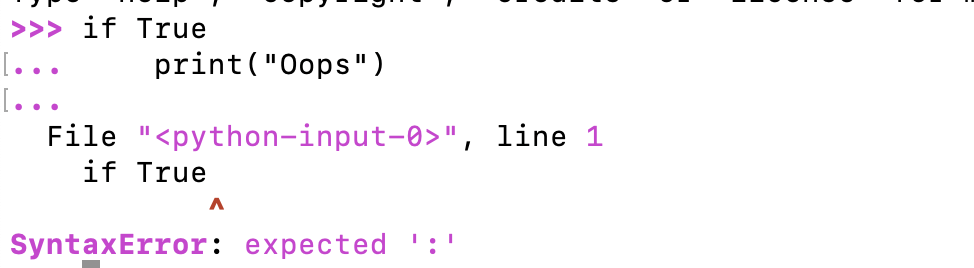

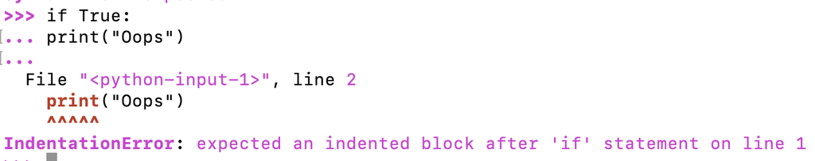

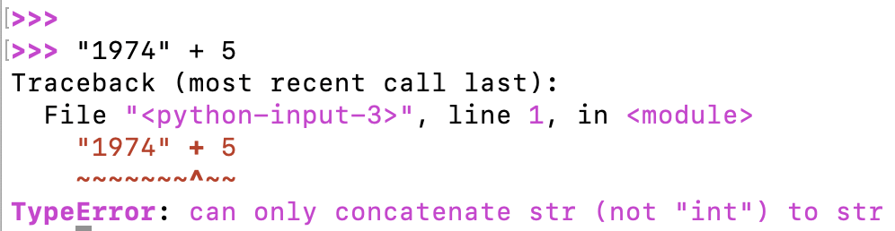

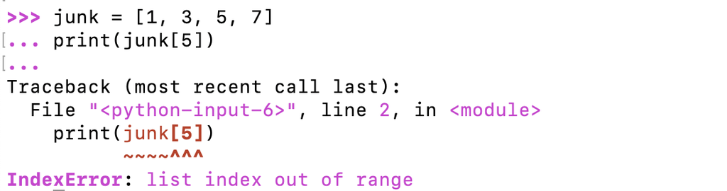

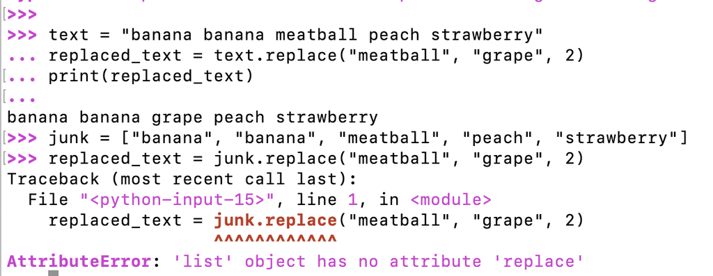

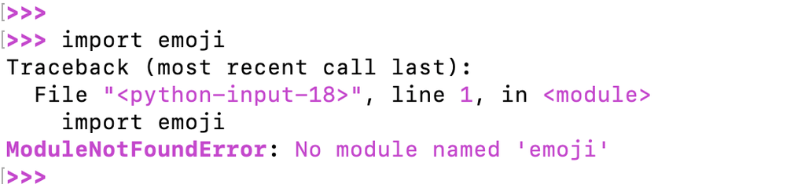

## Try/Except

- You are just starting to write Python functions
- The try/except system is like a safety net
  - You “try” risky code/uncertain
  - You plan to catch specific errors with “except”
  - You tell Python what it will print in response
  - Helps prevent your program from completely crashing.

## Simple Example - Volume again

```python
"""
computing sphere volume
"""

import math

PI = math.pi

r_input = input("What is the radius of your sphere? ")

try:
    r = float(r_input)
    if r > 0:
        volume = round((4/3) * PI * (r**3), 2)
        print(f"The volume of your sphere is {volume} cubic units.")
    else:
        print("Error: The radius must be a positive numerical value.")
except ValueError:
    print("Error: Please enter a valid numerical value for the radius.")
```

If a user is entering bad values like 0 or a string, a specific message is returned.

## More Complicated Example

```python
import requests

def fetch_weather():
     try:
         response = requests.get("https://api.weather.gov/points/34.06974489786188,-118.44321649871341")
         response.raise_for_status()  # raises an HTTPError if the response was an error
         return response.json()
     except requests.exceptions.HTTPError as e:
         print("Server returned an error:", e)
     except requests.exceptions.ConnectionError:
        print("Failed to connect to the weather server.")
     except Exception as e: # commbine all other errors and print
         print("Unexpected error:", e)

fetch_weather()
```

```
{'@context': ['https://geojson.org/geojson-ld/geojson-context.jsonld',
  {'@version': '1.1',
   'wx': 'https://api.weather.gov/ontology#',
   's': 'https://schema.org/',
   'geo': 'http://www.opengis.net/ont/geosparql#',
   'unit': 'http://codes.wmo.int/common/unit/',
   '@vocab': 'https://api.weather.gov/ontology#',
   'geometry': {'@id': 's:GeoCoordinates', '@type': 'geo:wktLiteral'},
   'city': 's:addressLocality',
   'state': 's:addressRegion',
   'distance': {'@id': 's:Distance', '@type': 's:QuantitativeValue'},
   'bearing': {'@type': 's:QuantitativeValue'},
   'value': {'@id': 's:value'},
   'unitCode': {'@id': 's:unitCode', '@type': '@id'},
   'forecastOffice': {'@type': '@id'},
   'forecastGridData': {'@type': '@id'},
   'publicZone': {'@type': '@id'},
   'county': {'@type': '@id'}}],
 'id': 'https://api.weather.gov/points/34.0697,-118.4432',
 'type': 'Feature',
 'geometry': {'type': 'Point', 'coordinates': [-118.4432, 34.0697]},
 'properties': {'@id': 'https://api.weather.gov/points/34.0697,-118.4432',
  '@type': 'wx:Point',
  'cwa': 'LOX',
  'forecastOffice': 'https://api.weather.gov/offices/LOX',
  'gridId': 'LOX',
  'gridX': 148,
  'gridY': 47,
  'forecast': 'https://api.weather.gov/gridpoints/LOX/148,47/forecast',
  'forecastHourly': 'https://api.weather.gov/gridpoints/LOX/148,47/forecast/hourly',
  'forecastGridData': 'https://api.weather.gov/gridpoints/LOX/148,47',
  'observationStations': 'https://api.weather.gov/gridpoints/LOX/148,47/stations',
  'relativeLocation': {'type': 'Feature',
   'geometry': {'type': 'Point', 'coordinates': [-118.402437, 34.07923]},
   'properties': {'city': 'Beverly Hills',
    'state': 'CA',
    'distance': {'unitCode': 'wmoUnit:m', 'value': 3901.1189930894},
    'bearing': {'unitCode': 'wmoUnit:degree_(angle)', 'value': 254}}},
  'forecastZone': 'https://api.weather.gov/zones/forecast/CAZ368',
  'county': 'https://api.weather.gov/zones/county/CAC037',
  'fireWeatherZone': 'https://api.weather.gov/zones/fire/CAZ368',
  'timeZone': 'America/Los_Angeles',
  'radarStation': 'KVTX'}}
```

## Fixing the pet calculator

- As a Python programmer you may decide to throw (raise) an exception when a condition occurs. To do this, use the raise keyword.

```python
def dog_to_human_years(dog_age):
    """15 human years equals the first year of a
    medium-sized dog’s life.
    Year two for a dog equals about nine years for a human.
    And after that, each human year would be
    approximately five years for a dog."""
    if dog_age <= 0:
        raise ValueError("Age must be a positive number.")
        # return "Age must be a positive number." # Not this way
    elif dog_age == 1:
        return 15
    elif dog_age == 2:
        return 24
    else:
        return 24 + (dog_age - 2) * 5

def bird_to_human_years(bird_age):
    if bird_age <= 0:
       raise ValueError("Age must be a positive number.")
       #return "Age must be a positive number." # Not this way
    return f"Your bird is {bird_age * 5} in human years"

def pet_age_calculator():
    """Calculates the human age of the pet based on the pet type and ask the user for input"""
    print("Welcome to the Pet Age Calculator!")
    print("Supported pets are: Dog, Bird")

    pet_type = input("What type of pet do you have? ").strip().lower()

    if pet_type in ["dog", "bird"]:
        try:
            pet_age = int(input(f"Enter your {pet_type}'s age in years: "))
            if pet_type == "dog":
                human_age = dog_to_human_years(pet_age)
            elif pet_type == "bird":
                human_age = bird_to_human_years(pet_age)
            print(f"Your {pet_type} is approximately {human_age} human years old!")
        except ValueError as e:
            print(f"Error: {e}")
    else:
        print("Sorry, this calculator only supports dogs and birds.")

# run it
if __name__ == "__main__":
    pet_age_calculator()
```

## Structure of the Previous examples

- Designed to address multiple types of failures
- Some were specific to internet related issues
- Provides interpretable error handling
- Will prevent a complete crash of our code
- Uses except ValueError: Catches the error
- Uses except ValueError as e: Catches the error AND give it a custom message so you can examine it further

## Recommendations from Python.org

PEP 8 is the style guide. Clear code is easier to debug than unclear. Main points of PEP 8:

- Use 4-space indentation, and no tabs.
- Wrap lines so that they don’t exceed 79 characters.
- Use blank lines to separate functions and classes, and larger blocks of code inside functions.
- When possible, put comments on a line of their own.
- Use docstrings.
- Use spaces around operators and after commas, but not directly inside bracketing constructs: a = f(1, 2) + g(3, 4).
- Name your classes and functions consistently; the convention is to use UpperCamelCase for classes and lowercase_with_underscores for functions and methods.

# More data structures

## Tuples

A Tuple is an immutable sequence, this means:

- It cannot be modified once created, you can make a new one
- Its elements have a definite order.
- A tuple can be indexed and sliced using index notation.
- Like a list, it can have mixed types of data
- Iterable

## Tuples v Lists

A Tuple is a lot like a list, but:

- Tuples are immutable, Lists are mutable
- Tuples need slightly less memory
- Tuples iterate a little faster
- Tuples are useful for fixed data that should be unchanging (e.g., an ID number)
- (optional) Tuple immutablility also allows the tuple to be hashable (hashable means to have a stable and unique integer representation throughout its existence) if all of its elements are hashable.

## Tuple operations

- Slice
- Max/Min
- Convert

Works like list slicing

```python
phy_sci = (2020, 3270, 2021, 3306, 2022, 3165, 2023, 3136, 2024, 3304)
print(f"{phy_sci[0]} Physical Science majors: {phy_sci[1]}") # Returns 2020 and 3270
print(phy_sci[0:4]) # Returns   2020, 3270, 2021, 3306
```

```
2020 Physical Science majors: 3270
(2020, 3270, 2021, 3306)
```

```python
phy_sci = (2020, 3270, 2021, 3306, 2022, 3165, 2023, 3136, 2024, 3304)
print(min(phy_sci[1::2]), max(phy_sci[1::2]))
```

```
3136 3306
```

```python
phy_sci = (2020, 3270, 2021, 3306, 2022, 3165, 2023, 3136, 2024, 3304)
phy_sci_list = list(phy_sci)
print(f"Is phy_sci_list a list? {isinstance(phy_sci_list, list)}")

phy_sci_tuple = tuple(phy_sci_list)
print(f"Is phy_sci_tuple a tuple? {isinstance(phy_sci_tuple, tuple)}")
```

```
Is phy_sci_list a list? True
Is phy_sci_tuple a tuple? True
```

## Example Tuple applications

- Constant
- Keys
- Swap
- Return Multiple values

```python
UCLA_COLORS = ("#2774AE", "#FFD100", "#FFFFFF")  # This will never change
```

They can serve as dictionary keys (more on dictionaries later):

```python
enrollment_data = {
    ("Sep", 2024): 47335,
    ("Sep", 2023): 46678,
    ("Sep", 2022): 46430
}
print(enrollment_data)
```

```
{('Sep', 2024): 47335, ('Sep', 2023): 46678, ('Sep', 2022): 46430}
```

You can easily swap two values using a tuple

```python
a, b = 5, 10
print(f"The original a, b is {a, b}")

a, b = b, a
print(f"The tuple swap is {a, b}")  # Output: 10, 5
```

```
The original a, b is (5, 10)
The tuple swap is (10, 5)
```

This is handy, in your functions, you can return multiple values using a tuple:

```python
def divide(a, b):
    quotient = a // b
    remainder = a % b
    return quotient, remainder  # Returns a tuple

x, y = divide(10, 3)
print(f"quotient: {x}, remainder: {y}")
```

```
quotient: 3, remainder: 1
```

## Sets

- Sets are iterable but not sequences
- Sets are *unordered* and cannot be indexed
- Sets cannot have *duplicates*
- Sets are mutable
- Sets are used where order and duplicate values don’t matter

## Set applications

- in
- Intersection
- Difference
- uniqueness
- Membership testing is very fast

```python
import time

# Large list vs tuple
large_set = set(range(10**6))
large_list = list(range(10**6))
large_tuple = tuple(range(10**6))


# Measure list iteration time
start = time.time()
999999 in large_list
end = time.time()
print(f"List iteration took: {end - start:.6f} seconds")

# Measure tuple iteration time
start = time.time()
999999 in large_tuple
end = time.time()
print(f"Tuple iteration took: {end - start:.6f} seconds")

# Measure set iteration time
start = time.time()
999999 in large_set
end = time.time()
print(f"Set iteration took: {end - start:.6f} seconds")
```

```
List iteration took: 0.007270 seconds
Tuple iteration took: 0.006188 seconds
Set iteration took: 0.000024 seconds
```

- Finding the intersection of two sets is fast

```python
import time

large_set_A = set([range(10**6), -6])
large_set_B = set([range(10**6+1,10**6+10**6+1), -6])

start = time.time()
set_numbers = large_set_A & large_set_B
end = time.time()
print(f"Set intersection took: {end - start:.6f} seconds")

print(set_numbers)  # Output: {-6}
```

```
Set intersection took: 0.000019 seconds
{-6}
```

- Finding the difference of two sets
- Something that list and tuples cannot do (programmers convert lists and tuples to sets if possible)

```python
import time

large_set_A = set([range(10**8), -6])
large_set_B = set([range(10**8), -7])

start = time.time()
in_A_only = large_set_A - large_set_B
end = time.time()
print(f"Set difference took: {end - start:.6f} seconds")

print(in_A_only)  # Output: {-6}
```

```
Set difference took: 0.000015 seconds
{-6}
```

```python
ingredients = set()
ingredients.add("banana")
ingredients.add("banana")
ingredients.add("meatball")

print(ingredients)
```

```
{'meatball', 'banana'}
```

## Dictionary

- A data structure with an unordered, mutable, and indexed collection of key-value pairs.
- A each value (name, number, anything really) in the dictionary has a label (called a key) and a value.
- The key-value pair allows us to store and retrieve values using unique keys (efficient for lookups by name not by position)
- Create using {} or dict()
- Keys must be immutable types (strings, numbers, tuples)
- Values can be any data type (lists, strings, numbers, tuples, other dictionaries, etc.).

## Example with unique IDs

```python
cities = [
    {
        "name": "Los Angeles",
        "founded": 1781,
        "country": "United States",
        "neighborhoods": ["DTLA", "Hollywood", "Westwood"]
        },
    {
        "name": "San Diego",
        "founded": 1769,
        "country": "United States",
        "neighborhoods": ["Balboa Park", "Hillcrest", "Old Town"]
        },
    {
        "name": "San Jose",
        "founded": 1777,
        "country": "United States",
        "neighborhoods": ["Almaden", "Northside", "South San Jose"]
        }
]

print(cities[1]['name'])   # Output: San Diego
print(cities[1]['neighborhoods'])    # Output: ["Balboa Park", "Hillcrest", "Old Town"]

for city in cities:
    print(f"{city['name']} and some of its neighborhoods are {city['neighborhoods']}")
```

```
San Diego
['Balboa Park', 'Hillcrest', 'Old Town']
Los Angeles and some of its neighborhoods are ['DTLA', 'Hollywood', 'Westwood']
San Diego and some of its neighborhoods are ['Balboa Park', 'Hillcrest', 'Old Town']
San Jose and some of its neighborhoods are ['Almaden', 'Northside', 'South San Jose']
```

## Example with unique IDs

```python
cities = {
    "city001": {
        "name": "Los Angeles",
        "founded": 1781,
        "country": "United States",
        "neighborhoods": ["DTLA", "Hollywood", "Westwood"]
        },
    "city002": {
        "name": "San Diego",
        "founded": 1769,
        "country": "United States",
        "neighborhoods": ["Balboa Park", "Hillcrest", "Old Town"]
        },
    "city003": {
        "name": "San Jose",
        "founded": 1777,
        "country": "United States",
        "neighborhoods": ["Almaden", "Northside", "South San Jose"]
        }
}
print(cities["city003"]["name"])   # Output: San Jose
print(cities["city001"]["neighborhoods"])    # Output: ['DTLA', 'Hollywood', 'Westwood']

for city_id, info in cities.items():
    print(f"{city_id}: {info['name']} and some of its neighborhoods are {info['neighborhoods']}")
```

```
San Jose
['DTLA', 'Hollywood', 'Westwood']
city001: Los Angeles and some of its neighborhoods are ['DTLA', 'Hollywood', 'Westwood']
city002: San Diego and some of its neighborhoods are ['Balboa Park', 'Hillcrest', 'Old Town']
city003: San Jose and some of its neighborhoods are ['Almaden', 'Northside', 'South San Jose']
```

## Usage examples

- Dictionaries are useful when you need to store and retrieve data by keys
- Lookup
- items
- keys
- values
- get

```python
import re # regular expressions (later)

file_path = "gettysburg.txt"

# Open and read the file creating a string
with open(file_path, "r", encoding="utf-8") as file:
    text = file.read()
    clean_text = re.sub(r'[^\w\s]', '', text).lower()


word_counts = {} # create a dictionary
for word in clean_text.split():
    word_counts[word] = word_counts.get(word, 0) + 1

print(word_counts)
# Output: {'Four': 1, 'score': 1, 'and': 6, 'seven': 1, ...}

most_common_word = max(word_counts, key=word_counts.get)

print(f"The most common word was '{max(word_counts, key=word_counts.get)}' with a count of {word_counts[most_common_word]}")
```

```
{'four': 1, 'score': 1, 'and': 6, 'seven': 1, 'years': 1, 'ago': 1, 'our': 2, 'fathers': 1, 'brought': 1, 'forth': 1, 'on': 2, 'this': 4, 'continent': 1, 'a': 7, 'new': 2, 'nation': 5, 'conceived': 2, 'in': 4, 'liberty': 1, 'dedicated': 4, 'to': 8, 'the': 11, 'proposition': 1, 'that': 13, 'all': 1, …
The most common word was 'that' with a count of 13
```

```python
my_items = list(word_counts.items())
my_items[0:5]
```

```
[('four', 1), ('score', 1), ('and', 6), ('seven', 1), ('years', 1)]
```

```python
my_keys = list(word_counts.keys())
my_keys[0:5]
```

```
['four', 'score', 'and', 'seven', 'years']
```

```python
my_values = list(word_counts.values())
my_values[0:5]
```

```
[1, 1, 6, 1, 1]
```

```python
word_counts.get('nation')
```

```
5
```

## Original Lecture 4 Start

- More about LEGB
- More about functions: arguments
- Inputting & Outputting data
- More about modules
- More advanced function writing

## LEGB, indentation, scope, again

- LEGB and Indentation are intertwined
  - Indentation defines the boundaries of functions and blocks.
  - Python determines scope (variable access) based on function definitions and indentation
  - Since each indentation level can create a new scope - if we declare a variable inside an indented block (like a function), it is *only accessible within that block unless explicitly returned* (or modified using global or nonlocal).

## Another Function & Scope Example

- mu1
- mu2
- mu3
- mu4
- explanation
- Why can’t I get mu?

```python
# Example
data = list(range(2, 50, 2)) # Example dataset
x = 20  # Data point for which we want the Z-score

def mean(data):
    return sum(data) / len(data)

def standard_deviation(data):
    mu = mean(data)
    variance = sum((x - mu) ** 2 for x in data) / len(data)  # Population formula
    return variance ** 0.5

def z_score(x, data):
    mu = mean(data)
    sigma = standard_deviation(data)
    return (x - mu) / sigma

print(f"mean of the data is: {mean(data):.4f}")
print(f"SD of the data is: {standard_deviation(data):.4f}")
print(f"Z-score of {x}: {z_score(x, data):.4f}")
print(f"x is {x}")

print(f"but why won't mu {mu} print?") # NameError
```

```
mean of the data is: 25.0000
SD of the data is: 13.8444
Z-score of 20: -0.3612
x is 20
```

```
---------------------------------------------------------------------------
NameError                                 Traceback (most recent call last)
Cell In[34], line 23
     20 print(f"Z-score of {x}: {z_score(x, data):.4f}")
     21 print(f"x is {x}")
---> 23 print(f"but why won't mu {mu} print?") # NameError

NameError: name 'mu' is not defined
```

- Suppose you think, maybe return mu in our function?

```python
# Example
data = list(range(2, 50, 2)) # Example dataset
x = 20  # single Data point for the Z-score

def mean(data):
    mu = sum(data) / len(data)
    return mu

def standard_deviation(data):
    variance = sum((x - mu) ** 2 for x in data) / len(data)  # Population standard deviation
    return variance ** 0.5

def z_score(x, data):
    sigma = standard_deviation(data)
    return (x - mu) / sigma


# even worse, only the first works now, so many errors
print(f"mean of the data is: {mean(data):.4f}")
print(f"SD of the data is: {standard_deviation(data):.4f}")
print(f"Z-score of {x}: {z_score(x, data):.4f}")
print(f"x is {x}")

print(f"but why won't mu {mu} print?")
```

```
mean of the data is: 25.0000
```

```
---------------------------------------------------------------------------
NameError                                 Traceback (most recent call last)
Cell In[35], line 20
     18 # even worse, only the first works now, so many errors
     19 print(f"mean of the data is: {mean(data):.4f}")
---> 20 print(f"SD of the data is: {standard_deviation(data):.4f}")
     21 print(f"Z-score of {x}: {z_score(x, data):.4f}")
     22 print(f"x is {x}")

Cell In[35], line 10, in standard_deviation(data)
      9 def standard_deviation(data):
---> 10     variance = sum((x - mu) ** 2 for x in data) / len(data)  # Population standard deviation
     11     return variance ** 0.5

Cell In[35], line 10, in <genexpr>(.0)
      9 def standard_deviation(data):
---> 10     variance = sum((x - mu) ** 2 for x in data) / len(data)  # Population standard deviation
     11     return variance ** 0.5

NameError: name 'mu' is not defined
```

standard deviation is trying to find “mu” in its local scope (not there), failing that, it moves to its enclosing score (in this example, global) and it cannot find it there as well so a NameError is the result.

```python
# Example
data = list(range(2, 50, 2)) # Example dataset
x = 20  # single Data point for the Z-score

def mean(data):
    mu = sum(data) / len(data)
    return mu

def standard_deviation(data, mu):
    variance = sum((x - mu) ** 2 for x in data) / len(data)  # Population standard deviation
    return variance ** 0.5

def z_score(x, data, mu):
    sigma = standard_deviation(data, mu)
    return (x - mu) / sigma

# this works, the other functions can see mu
print(f"mean of the data is: {mean(data):.4f}")
print(f"SD of the data is: {standard_deviation(data, mean(data)):.4f}")
print(f"Z-score of {x}: {z_score(x, data, mean(data)):.4f}")
print(f"x is {x}")

print(f"but why won't mu {mu} print?")
```

```
mean of the data is: 25.0000
SD of the data is: 13.8444
Z-score of 20: -0.3612
x is 20
```

```
---------------------------------------------------------------------------
NameError                                 Traceback (most recent call last)
Cell In[36], line 23
     20 print(f"Z-score of {x}: {z_score(x, data, mean(data)):.4f}")
     21 print(f"x is {x}")
---> 23 print(f"but why won't mu {mu} print?")

NameError: name 'mu' is not defined
```

This works because mu is properly passed to the other two functions but it will not print because it’s not in the global scope.

- make global (call it mu2) OR (absolute last resort) use global keyword

```python
# constants
data = list(range(2, 50, 2)) # Example dataset
x = 20  # Data point for which we want the Z-score

def mean(data):
    global mu
    mu = sum(data) / len(data)
    return mu

mu2 = mean(data)

def standard_deviation(data):
    variance = sum((x - mu2) ** 2 for x in data) / len(data)  # Population standard deviation
    return variance ** 0.5

def z_score(x, data):
    sigma = standard_deviation(data)
    return (x - mu2) / sigma


print(f"mean of the data is: {mean(data):.4f}")
print(f"SD of the data is: {standard_deviation(data):.4f}")
print(f"Z-score of {x}: {z_score(x, data):.4f}")
print(f"x is {x}")
print(f"but mu2 {mu2} prints")
print(f"and mu {mu} prints having been made global")
```

```
mean of the data is: 25.0000
SD of the data is: 13.8444
Z-score of 20: -0.3612
x is 20
but mu2 25.0 prints
and mu 25.0 prints having been made global
```

- To avoid frustration & errors one must understand where Python expects to find and store variables when used *inside* a function.
- If you assign a value to a variable inside a function, Python assumes it is a local variable.
- If Python assumes a variable is local, but the variable actually originates from an enclosing or global scope, you get an UnboundLocalError.
- If the variable doesn’t exist at all or not visible at all, a NameError will result

## UnboundLocalErrors Example

- Error
- Possible fix
- Possible Fix
- Possible Fix

```python
# modifying a global variable will not work

x = 12

def my_fun():
    x += 2
    return x

print(my_fun())
print(x)
```

```
---------------------------------------------------------------------------
UnboundLocalError                         Traceback (most recent call last)
Cell In[38], line 9
      6     x += 2
      7     return x
----> 9 print(my_fun())
     10 print(x)

Cell In[38], line 6, in my_fun()
      5 def my_fun():
----> 6     x += 2
      7     return x

UnboundLocalError: cannot access local variable 'x' where it is not associated with a value
```

```python
# not modifying a global works

x = 12

def my_fun():
    y = x + 2
    return y

print(my_fun())
# print(y) # by now, you should be able to see why this is an error
```

```
14
```

```python
# passing a global works
x = 12

def my_fun(z):
    z += 2
    return z

print(my_fun(x))
print(x)
# print(z) # will throw a name error
```

```
14
12
```

```python
# not recommended, can create undesirable results
x = 12

def my_fun():
    global x
    x += 2
    return x

print(my_fun())
print(x)
```

```
14
14
```

## A benefit of arguments

- When you pass a variable as an argument to a function, Python doesn’t care whether it’s global, enclosing, or local
- To Python, function arguments are just values being copied into the function’s local symbol table.
- So if scoping rules confuse you, a possible solution is to program functions with arguments

## But beware of mutable objects (lists, dictionaries)

- Python does not pass arguments by “value” or “reference”, but instead passes “references to objects.” This means:
  - If the object is immutable (like int, str, tuple), Python creates a new local copy.
  - If the object is mutable (like list, dict), modifications inside the function affect the original object.

## Examples using mutable list

You can use lists, just be aware of their behavior.

- Nested list
- Nested List reassigned
- shallow copied
- shallow fail
- deepcopy

```python
original_list = [1, 2, 3, [4, 5]]  # Global list

def modify_list(lst):
    lst.append(6)  # Modifies the original list.
    return lst

new_list = modify_list(original_list)

print(new_list)
print(original_list)  # prints [1, 2, 3, [4, 5], 6] globally
```

```
[1, 2, 3, [4, 5], 6]
[1, 2, 3, [4, 5], 6]
```

```python
original_list = [1, 2, 3, [4, 5]] # Global list

def modify_list(lst):
    new_list = original_list
    new_list.append(6)
    new_list[0] = 10
    return new_list

new_list = modify_list(original_list)

print(new_list) # modified
print(original_list)  # modified too
```

```
[10, 2, 3, [4, 5], 6]
[10, 2, 3, [4, 5], 6]
```

```python
original_list = [1, 2, 3, [4, 5]] # Global list

def modify_list(lst):
    new_list = original_list.copy()
    new_list.append(6)
    new_list[0] = 10
    return new_list

new_list = modify_list(original_list)

print(new_list) # modified
print(original_list)  # prints [1, 2, 3, [4, 5]]
```

```
[10, 2, 3, [4, 5], 6]
[1, 2, 3, [4, 5]]
```

Unfortunately, if you modify the nested elements…

```python
original_list = [1, 2, 3, [4, 5]] # Global list

def modify_list(lst):
    new_list = original_list.copy()
    new_list.append(6)
    new_list[0] = 10
    new_list[3][0] = 40 # this happens
    return new_list

new_list = modify_list(original_list)

print(new_list) # modified
print(original_list)  # prints [1, 2, 3, [40, 5]]
```

```
[10, 2, 3, [40, 5], 6]
[1, 2, 3, [40, 5]]
```

Use the *copy* module from the Python Standard Library and it’s **deepcopy** function:

```python
import copy

original_list = [1, 2, 3, [4, 5]] # Global list

def modify_list(lst):
    new_list = copy.deepcopy(original_list)
    new_list.append(6)
    new_list[0] = 10
    new_list[3][0] = 40
    return new_list

new_list = modify_list(original_list)

print(new_list) # modified
print(original_list)  # stays unmodified
```

```
[10, 2, 3, [40, 5], 6]
[1, 2, 3, [4, 5]]
```

## Back to Parameters & Arguments

One of the most important and useful functions in Python has very many parameters (you don’t need this many):

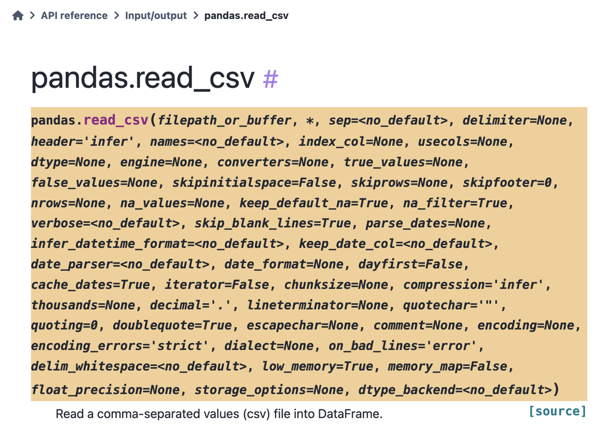

## Some definitions

- Parameter: A variable that is in a function definition. It acts as a stand-n for the value that will be passed when the function is called.
- Argument: When the function is called the argument is the actual value passed to it.

As you can see from the read_csv() example, one can program a function to have multiple parameters which can accept multiple arguments.

## Example: Multiple arguments

You’ve seen this about two lectures ago. What if we rewrite it to have multiple parameters? Orginally, name was only parameter. We could add the number of attempts and even a text to print out.

```python
def name_to_a1z26(name = None, attempts=3, suggestion="Too many invalid attempts. Please try again later"):
    while attempts > 0:
        if not name or name.strip() == "":
            name = input("Enter your name (or type 'exit' to quit): ")

        if name.lower() == "exit":
            print("Exiting the script")
            return

        elif name.isalpha():  # Check the name is in A-Z or a-z after removing spaces
            cipher_values = [ord(char) - 64 for char in name if char.isalpha()]
            print(f"Your name in A1Z26 cipher is: {cipher_values}")
            return

        attempts -= 1
        print(f"Invalid input. {attempts} attempts left.")

        if attempts == 0:
            print(suggestion)
            return

        name = None

if __name__ == "__main__":
    name_to_a1z26()
```

## (aside) if **name** == “**main**”:

- Recall - inclusion of `if __name__ == "__main__":` stops accidental execution if this script is imported into another program.
- Is useful when testing. Here it is imported into the REPL:

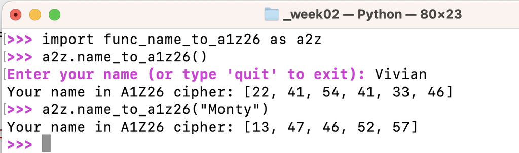

## Next time - More Functions

Have a terrific weekend!